# **Report Rbootcamp**

Irmak Ozarslan, Barbara Maier

2025-01-28

#### **Table of Contents**

##### **1. Introduction**

##### **2. Data**

```
 2.1. Data Source
 2.2. Data Description
```

##### **3. Processing**

```
 3.1 Data Preperation
 3.2.Data Merging
```

##### **4. Visual Inspection of the given Data**

```
 4.1 Suicide Rates
 4.2 Mental Health Rates
 4.3 Drug Deaths
 4.4 Unemployment
```

##### **5. Hypothesis / Model Description**

##### **6. Data Analysis**

[output not shown]

##### **7. Results**

```
 7.1 GLM Model for suicide deaths
 7.2 GLM Model for drug overdoses
 7.3 GLMM
```

##### **8. Chapter of Choice**

```
 8.1 Interactive Map (Shiny App)
```

##### **9. Summary and Conclusion**

[output not shown]

## **1. Introduction**

The primary focus of this work is to explore the process of data analysis and visualization using R. With this goal in mind, we decided to advance our skills in problem solving and user centered visualizations while exploring a topic that has a potential to have a real world impact. Therefore, we selected a topic that aligns with our background in psychology and social sciences.

Suicides remain significant global public health concerns, affecting millions of individuals and their families each year. Understanding the factors that contribute to these issues are crucial for developing effective intervention strategies. By leveraging data from multiple sources, we seek to identify trends, correlations, and possible intervention points that could help mitigate these crises. Substance use disorders are considered to be comorbid with certain mental health conditions. In conditions such as bipolar disorder, substance use is an established risk factor (Lalli et al., 2021). Furthermore, economic difficulties are known to be associated with poor mental health (Junna et al., 2022). Thus, in our study we wanted to explore the relationship between mental health conditions across the world and unemployment, drug deaths and suicide rates to determine its key predictors.

Our research questions are the following :

**Can mental health issues and other factors predict suicide rates?**

**Can we predict mental health conditions from drug deaths and unemployment?**

## **2. Data**

### **2.1. Data Source**

To compare suicide rates with mental health issues and other contributing factors, we used the following data sources:

1. World Suicide Rates: http://ourworldindata.org/suicide
2. World Unemployment Rates: https://ourworldindata.org/grapher/unemployment-rate (download of full data)
3. World Mental Health Conditions: https://www.kaggle.com/datasets/imtkaggleteam/mental-health
4. World Drug Overdoses: https://www.kaggle.com/datasets/programmerrdai/cocaineopioidscannabis-and-illicit-drugs/data?select=deaths-drug-overdoses.csv

The data were downloaded in .csv format,and each covered different year spans. Common years in 4 datasets included the period from 2000 to 2019. The datasets were retrieved on 28.01.2025.

### **2.2. Description of the Data Source:**

#### **Data 1: Suicide Deaths:**

The data is sourced from Our World in Data, which compiles information from the World Health Organization (WHO).

The dataset includes the age-standardized death rate from self-harm among both sexes. It estimates the number of age-standardized deaths from self-harm per 100,000 people.

Source: World Health Organization (2024) – with significant processing by Our World in Data.

Last Updated: July 30, 2024.

Date Range: 2000–2021, worldwide

Unit of Measurement: Deaths per 100,000 people.

#### **Data 2: Unemployment:**

The dataset includes the unemployment rate, defined as the percentage of the labor force that is without work but actively seeking and available for employment.

Source: Multiple sources compiled by World Bank (2025) – processed by Our World in Data

Last updated: January 24, 2025

Date range: 1991–2023, worldwide

Unit modeled ILO estimate

#### **Data 3: Mental Health Disorders:**

The dataset includes percentage of various mental health conditions in most of the countries of the world. The mental health conditions covered are: Schizophrenia, Bipolar Disorder, Depressive Disorder, Eating Disorder, Anxiety Disorder.

Source: Kaggle, Ourworldindata

Last updated: 2023

Date range: 1990–2019, worldwide

Unit of Measurement: Share of population, age-sex standardized

#### **Data 4: Drug Overdoses:**

The dataset includes absolute rates of drug overdose deaths in most of the countries of the world. The substances covered are: Cocaine, opioids, amphetamines, other drugs.

Source: Kaggle, Ourworldindata

Last updated: 2022

Date range: 1990–2019, worldwide

Unit of Measurement: Share of population, age-sex standardized

## **3. Data Processing**

### **3.1 Data Preperation**

We began by cleaning each table individually in R.

-Please check the script, preprocessing_data for detailed code.

**Steps taken in all the tables:**

- Reading in Data
- Removing missing Values (NAs)
- Filtering the Years 2000 - 2019 and assuring it is integer
- Name matching of Country.Name and Year columns
- Rename Columns for Simplicity
- Dropping unnecessary columns
- Saving the modified table in an output file

**Steps taken in specific tables:**

- Calculating percentages from absolute numbers divided by population for table 4 (Drug Overdoses)

### **3.2 Data Merging**

- Merging all the 4 tables was done with the Columns Year and Country.Name
- We did visual inspection of Country.Name in different datasets, if not matched it was standardized. However, since all datasets are based on ourworldindata, the Country.Name’s were identical and there were missing columns only due to missing data and not mismatch of names.
- Creating a new Column “Continents”.

  Below you can see a code snippet of merging the 4 datasets:

```r
#Merge the 4 tables:

new_table <- mental_health %>%
    full_join(suicide, by = c("Country.Name","Year")) %>%
    full_join(unemployment, by = c("Country.Name","Year")) %>%
    full_join(drugdeaths, by = c("Country.Name","Year"))

#write.csv(new_table,"new_data_merged.csv")
```

[output not shown]

### **4. Visual Inspection of given Data**

#### **4.1 Suicide Rates**

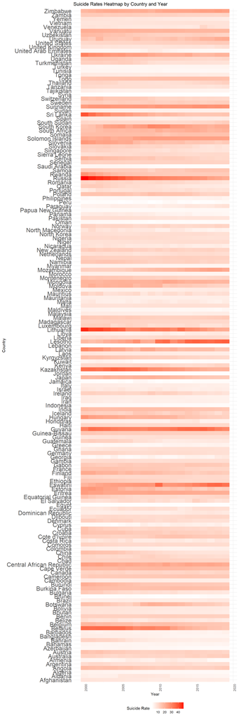

### **Suicide Rates Heat Map Analysis**

This heatmap visualizes suicide rates across different countries from 2000 to 2019. Each row represents a country, while each column represents a year. The intensity of the red color indicates the suicide rate, with darker shades representing higher rates.

### **Countries with High Suicide Rates**

- **Lithuania & Russia:** These countries show consistently high suicide rates throughout the years, with dark red shades dominating their rows. Lithuania, in particular, remains one of the countries with the highest suicide rates.

### **Countries with Lower Suicide Rates**

- Several countries, particularly in the **Middle East and some African nations**, show consistently lighter shades, indicating relatively low suicide rates.
- **Saudi Arabia** and **Kuwait**, for instance, have very light colors throughout the timeline, suggesting comparatively low suicide rates.
- **Afghanistan & Pakistan:** These countries also show relatively low reported suicide rates, though underreporting due to cultural stigma may be a contributing factor.

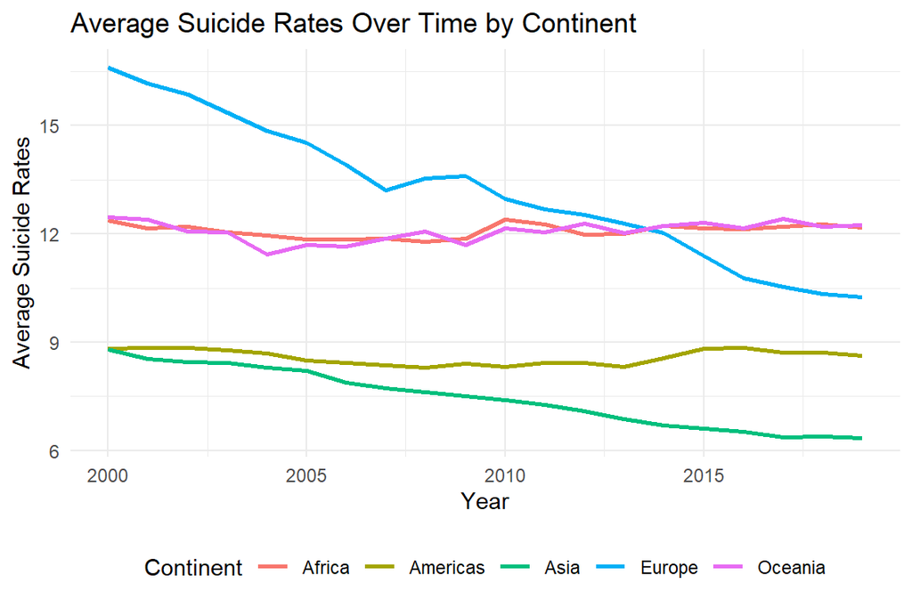

### **Description:**

This line chart visualizes the trends in average suicide rates across different continents from the year 2000 to 2019. Each colored line corresponds to a different continent.

### **Key Insights**

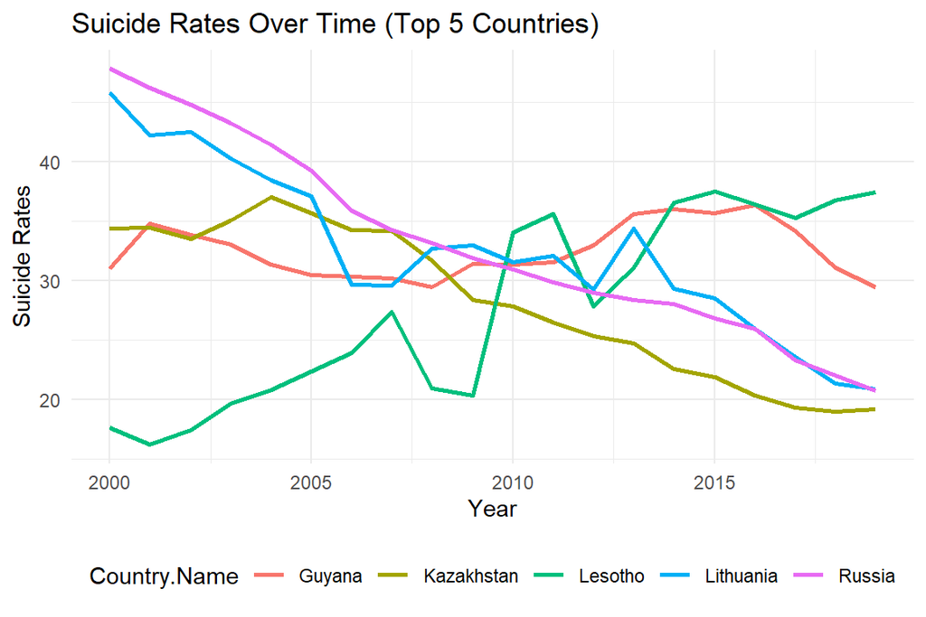

### **Description:**

This line chart illustrates the suicide rates of the **top five countries** with the highest recorded suicide rates from **2000 to 2019**. The x-axis represents the years, while the y-axis shows the suicide rates per 100,000 people. Each colored line corresponds to a different country.

### **Key Insights**

- **Russia** (purple) had the highest suicide rates initially but showed a strong decline.
- **Lithuania** (blue) and **Kazakhstan** (yellow-green) also exhibited decreasing trends.
- **Lesotho** (green) experienced an increase over time, surpassing some other countries.
- **Guyana** (red) remained relatively stable but had a slight decrease in recent years.

### **4.2 Mental Health Percentages**

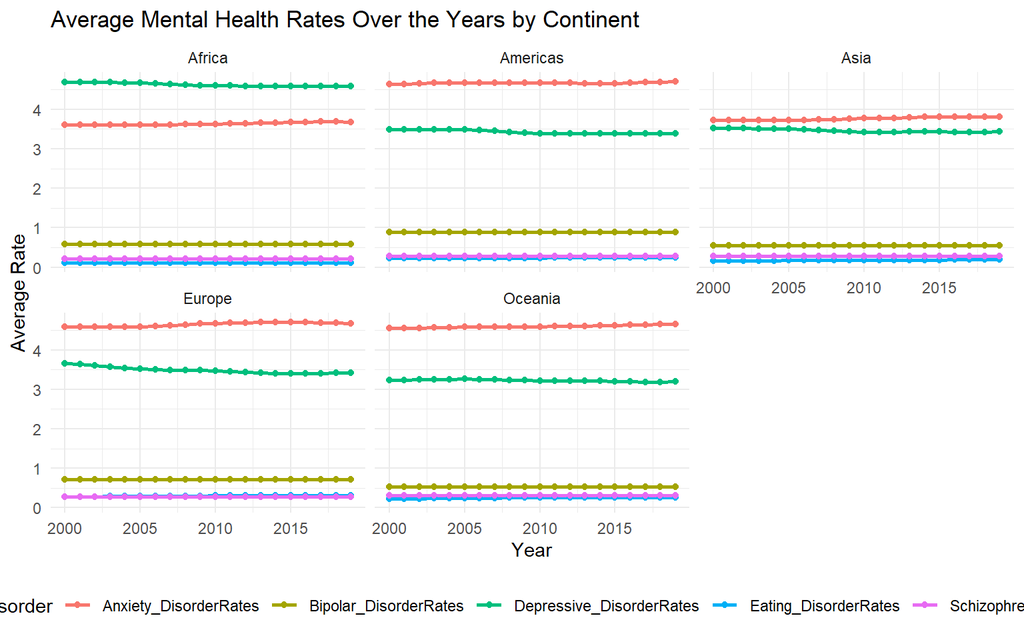

### **Description:**

- **Anxiety Disorders (Red)**
- **Bipolar Disorders (Yellow)**
- **Depressive Disorders (Green)**
- **Eating Disorders (Blue)**
- **Schizophrenia (Purple)**

### **General Trends**

- **Anxiety and depressive disorders** are the most prevalent mental health conditions across all continents.
- **Bipolar disorder, eating disorders, and schizophrenia** show much lower rates compared to anxiety and depressive disorders.
- Most continents show **relatively stable trends** over time, with **small increases or decreases** in specific disorders.

### **Specific Insights**

- **Europe** shows a slight **decrease in depressive disorders**, while **anxiety disorder rates have slightly increased** over time.
- **Africa, Asia, and the Americas** display **consistent trends** without significant deviations, suggesting stable reporting or prevalence of disorders in these regions.

### **4.3 Drug Overdoses**

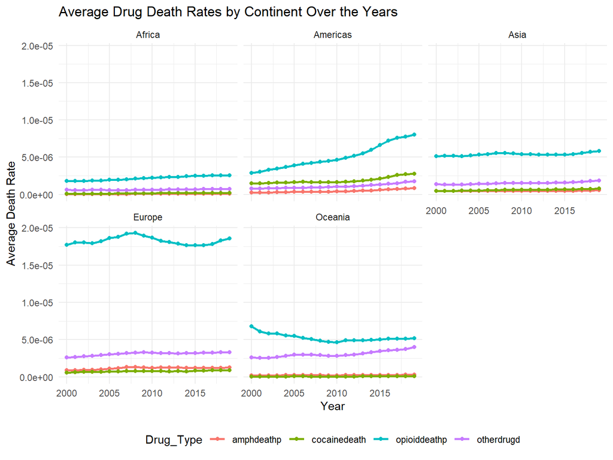

### **Description:**

- **Amphetamine-related deaths (Red)**
- **Cocaine-related deaths (Green)**
- **Opioid-related deaths (Blue)**
- **Other drug-related deaths (Purple)**

### **General Trends**

- **Opioid-related deaths** (blue line) are the most prevalent across all continents, particularly in **the Americas and Europe**.
- **Cocaine, amphetamine, and other drug-related deaths** show significantly lower rates compared to opioid-related deaths.
- **Most continents display relatively stable trends**, but some regions exhibit noticeable fluctuations.

### **Specific Insights**

- **The Americas show a steady rise in opioid-related deaths**, particularly after **2010**, indicating an increasing opioid crisis.
- **Europe has consistently high opioid-related death rates**, with **small fluctuations over time**.
- **Oceania exhibits a little decline in drug-related deaths**, particularly in **opioid related deaths**, possibly due to policy changes, public health interventions, or data collection modifications.
- **Africa and Asia** show **minimal variation** in drug death rates, remaining at consistently low levels.

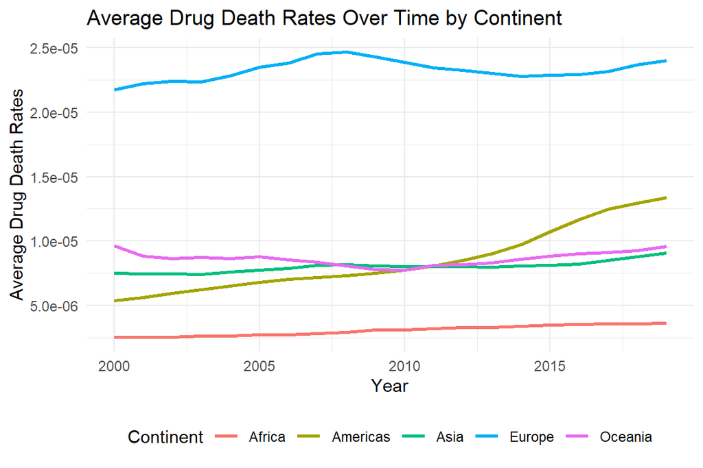

### **4.4 Unemployment**

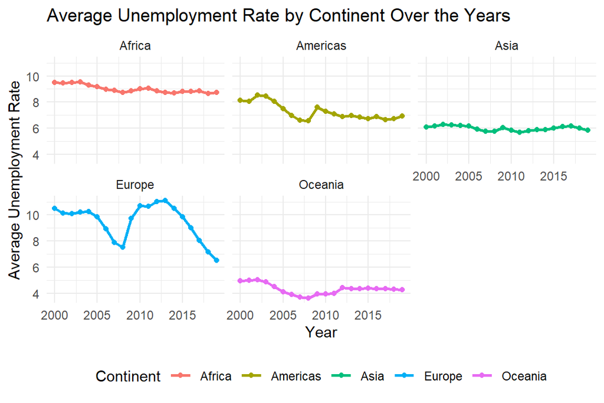

### **Description:**

This line chart visualizes the trends in the **average unemployment rate** across different continents from the year **2000 to 2019**. The x-axis represents the **years**, while the y-axis shows the **average unemployment rate in percentage**. Each colored line corresponds to a different continent:

## 5. **Hypothesis:**

This study investigates the relationship between mental health issues, unemployment rates, with suicide rates and drug-related deaths across countries over the past 19 years.These variables are measured as the percentage of the population, across most of the countries in the world, from the years 2000 to 2019.

The final dataset includes the following variables:

- Schizophrenia Rates
- Depressive Disorder Rates
- Anxiety Disorder Rates
- Bipolar Disorder Rates
- Eating Disorder Rates
- Unemployment Rates
- Suicide Rates
- Opioid Death Rates
- Cocaine Death Rates
- Amphetamine Death Rates
- Other Drug Death Rates
- Total Drug Deaths

#### **Hypothesis 1:** We would expect that higher the mental health disorder percentages and unemployment, there will be higher suicide rates.

#### **Hypothesis 2:** We would expect to find a positive relationship between mental health conditions, drug overdoses and unemployment.

### **5.1 Model Descriptions:**

Given that we are analyzing multiple predictors simultaneously, we expand the analysis using a generalized linear model (GLM). GLMs allow us to have flexibility in our analysis and model the relationships between the predictor and response variables while accounting for non-normal distributions or complex interactions between predictors.

Where:

Suicide Rates are the dependent variable (the rate of suicide in country$_i$

Schizophrenia Rates, Depressive Disorder Rates, Anxiety Disorder Rates, Unemployment Rates are the independent variables.

## **6. Data Analysis**

### **6.1 Exploratory Analysis:**

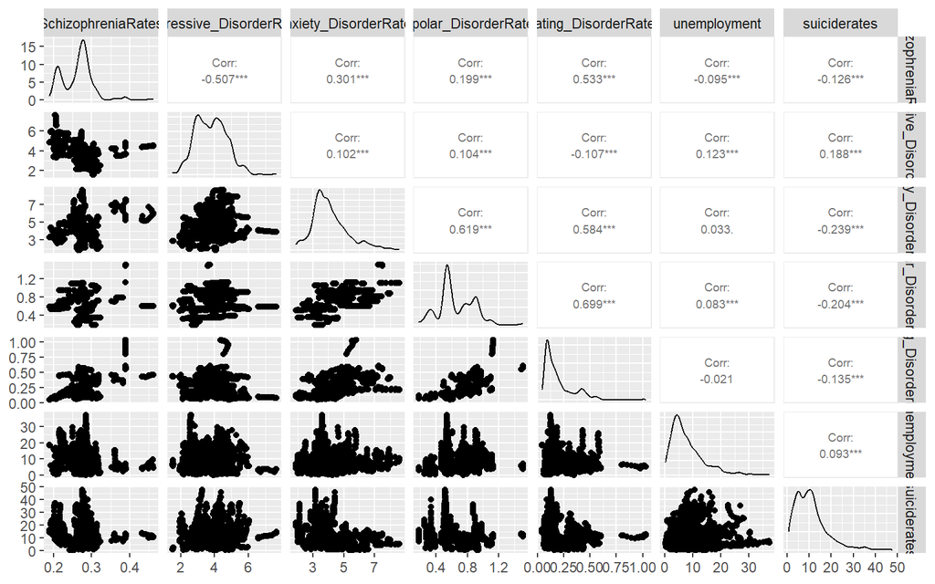

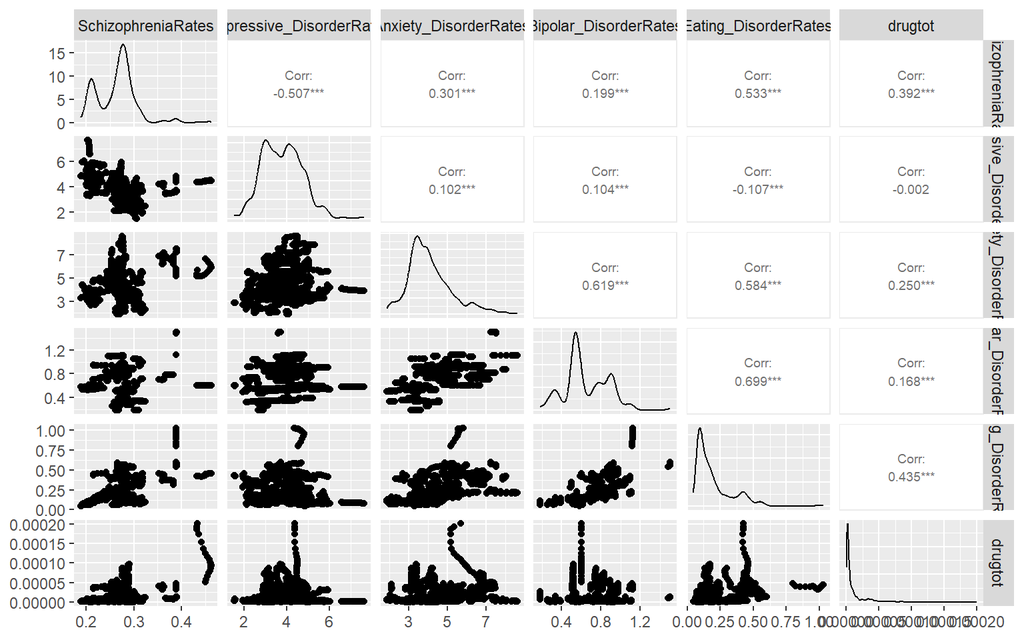

```
##                          SchizophreniaRates Depressive_DisorderRates
## SchizophreniaRates                1.0000000             -0.507163061
## Depressive_DisorderRates         -0.5071631              1.000000000
## Anxiety_DisorderRates             0.3013746              0.102232515
## Bipolar_DisorderRates             0.1990508              0.103644600
## Eating_DisorderRates              0.5325262             -0.106894960
## drugtot                           0.3917556             -0.002148956
## suiciderates                     -0.1257615              0.187811832
##                          Anxiety_DisorderRates Bipolar_DisorderRates
## SchizophreniaRates                   0.3013746             0.1990508
## Depressive_DisorderRates             0.1022325             0.1036446
## Anxiety_DisorderRates                1.0000000             0.6188341
## Bipolar_DisorderRates                0.6188341             1.0000000
## Eating_DisorderRates                 0.5839650             0.6989271
## drugtot                              0.2500191             0.1680004
## suiciderates                        -0.2391765            -0.2042225
##                          Eating_DisorderRates      drugtot suiciderates
## SchizophreniaRates                  0.5325262  0.391755558   -0.1257615
## Depressive_DisorderRates           -0.1068950 -0.002148956    0.1878118
## Anxiety_DisorderRates               0.5839650  0.250019126   -0.2391765
## Bipolar_DisorderRates               0.6989271  0.168000353   -0.2042225
## Eating_DisorderRates                1.0000000  0.434521154   -0.1353976
## drugtot                             0.4345212  1.000000000    0.1845238
## suiciderates                       -0.1353976  0.184523795    1.0000000
```

#### **Description:**

**Key Elements in the Image:**

**Diagonal Plots:** These show the density distributions of individual variables such as Schizophrenia Rates, Depressive Disorder Rates, Anxiety Disorder Rates, Bipolar Disorder Rates, Eating Disorder Rates, unemployment and suicide rates in the first scatterplot matrix and total drug deaths instead of suicide rates in the second.

**Lower Triangle Scatterplots**: The black dots represent data points for pairwise comparisons, showing how one variable relates to another.

**Upper Triangle** is showing the Correlation Values. Each cell contains a correlation coefficient (Corr) between two variables.

Values range from -1 to 1 (negative to positive correlation).

Significance levels are marked with asterisks: (*) p < 0.05,(***) p < 0.001 (highly significant correlations).

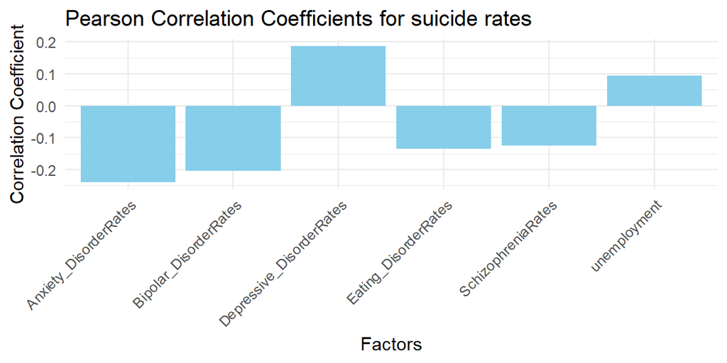

### **Description:**

This bar chart illustrates the Pearson correlation coefficients between various psychological and socio-economic factors and suicide rates. Pearson’s correlation measures the strength and direction** of a linear relationship between two variables, with values ranging from -1 (strong negative correlation) to +1 (strong positive correlation).

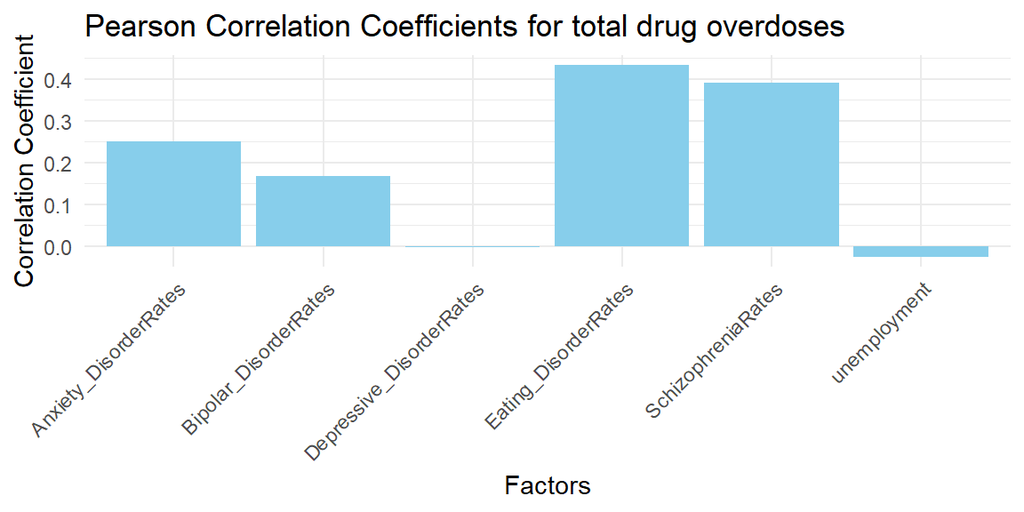

### **Description:**

This bar chart illustrates the Pearson correlation coefficients between various psychological and socio-economic factors and drug death rates. A positive correlation suggests that as the factor increases, drug death rates also tend to rise, whereas a negative correlation indicates an inverse relationship.

Significance levels are marked with asterisks: (*) p < 0.05, (***) p < 0.001 (highly significant correlations).

### **6.2 Generalized Linear Modelling (Multivariate Analysis)**

#### **6.2.1: Model 1: Relationship between mental health conditions, unemployment and suicide rates:**

```r
#GLM Model 1 with gaussian dist:
gaussian_model <- glm(suiciderates ~ SchizophreniaRates + Depressive_DisorderRates +
                 Anxiety_DisorderRates + Bipolar_DisorderRates + Eating_DisorderRates +
                 unemployment,family=gaussian(link = "identity"), data = end_data)
#GLM Model 1 with Gamma dist:
gamma_model <- glm(suiciderates ~ SchizophreniaRates + Depressive_DisorderRates +
                 Anxiety_DisorderRates + Bipolar_DisorderRates + Eating_DisorderRates +
                 unemployment,family=Gamma(link = "log"), data = end_data)
```

Summary of GLM Gaussian Model 1 Results

| Predictor | Estimate | Std_Error | t_value | p_value |
| --- | --- | --- | --- | --- |
| (Intercept) | 8.5559081 | 1.39604014783525 | 6.12869774545464 | 9.88318333231626e-10 |
| SchizophreniaRates | 8.6933628 | 4.06752885714705 | 2.13725903673624 | 0.0326486450400318 |
| Depressive_DisorderRates | 2.0100258 | 0.149314277499983 | 13.4617120795705 | 2.82859493639372e-40 |
| Anxiety_DisorderRates | -1.5081897 | 0.131651790328134 | -11.4558997537585 | 7.77065957300261e-30 |
| Bipolar_DisorderRates | -6.4974127 | 0.803972470465528 | -8.08163574483328 | 8.81507202148308e-16 |
| Eating_DisorderRates | 7.7806346 | 1.36326742170119 | 5.70734286008038 | 1.24670275243774e-08 |
| unemployment | 0.1149853 | 0.0199074795339571 | 5.77598430924706 | 8.34431977938059e-09 |
| AIC | 22275.1688778 |  |  |  |

Summary of GLM Gamma Model 1 Results

| Predictor | Estimate | Std_Error | t_value | p_value |
| --- | --- | --- | --- | --- |
| (Intercept) | 2.0376396 | 0.132214917695356 | 15.4115707080582 | 7.68960539754367e-52 |
| SchizophreniaRates | 1.2204134 | 0.385223873328498 | 3.16806270452041 | 0.00154829847890504 |
| Depressive_DisorderRates | 0.2094748 | 0.0141411226181524 | 14.8131694992802 | 3.80328457907448e-48 |
| Anxiety_DisorderRates | -0.1558580 | 0.0124683596311119 | -12.5002820663128 | 4.40327463221243e-35 |
| Bipolar_DisorderRates | -0.7097772 | 0.0761419033519631 | -9.32176906192915 | 2.00881561732115e-20 |
| Eating_DisorderRates | 1.0090999 | 0.129111107754656 | 7.81574844539604 | 7.24504752505491e-15 |
| unemployment | 0.0086681 | 0.00188537970930528 | 4.59755415062143 | 4.43170395782967e-06 |
| AIC | 21198.2429904 |  |  |  |

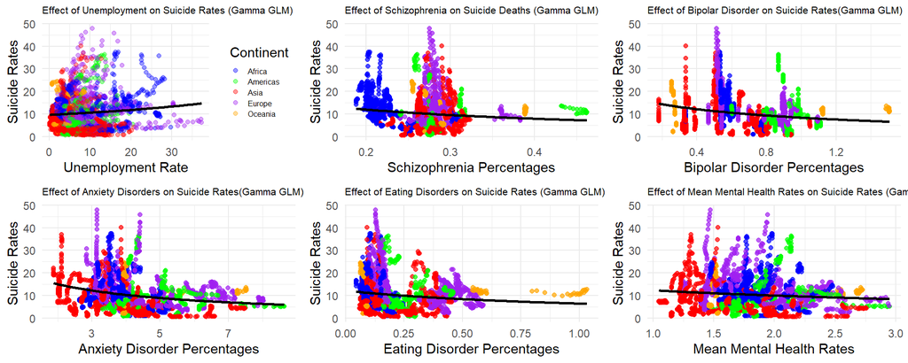

### **Description**

These scatterplots show relationships between different mental health factors (schizophrenia, bipolar disorder, anxiety, eating disorders, and mean mental health) and suicide rates. Each point represents data from a country or region, colored by continent. Regression lines (black lines) suggest the overall trend of the relationship.

#### **6.2.1.1 Checking Normality Assumptions and Model Selection:**

```
##                df      AIC
## gaussian_model  8 22275.17
## gamma_model     8 21198.24
```

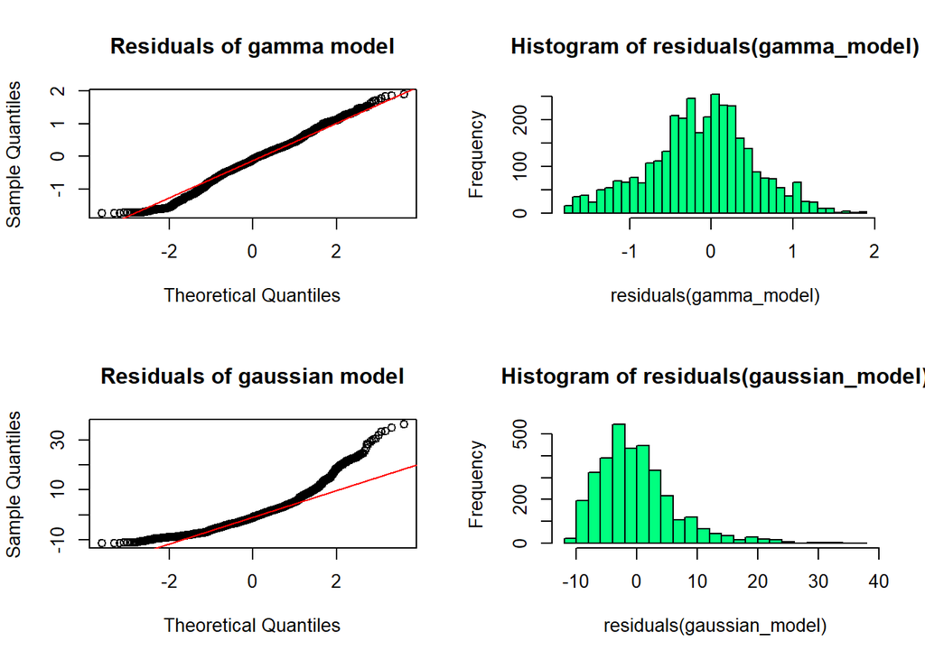

```
##
##  Shapiro-Wilk normality test
##
## data:  gaussian_model[["residuals"]]
## W = 0.91755, p-value < 2.2e-16
```

```
##
##  Shapiro-Wilk normality test
##
## data:  gamma_model[["residuals"]]
## W = 0.92691, p-value < 2.2e-16
```

### **Description:**

**Residual plots (QQ plots):** These assess whether the residuals (errors) from two models (Gamma and Gaussian) follow a normal distribution.

**Histograms of residuals:** These plots shows where the residuals are centered.

**Shapiro Wilks Test:** This test checks whether the residuals follow a normal distribution.

**AIC:** This score allows us to compare the two models.

#### 6.2.2: **Model 2: Relationship between mental health conditions, unemployment and drug overdoses :**

```r
#  GLM model 2, gaussian dist.
glm_model1 <- glm(drugtot_adj ~ SchizophreniaRates + Depressive_DisorderRates +
                 Anxiety_DisorderRates + Bipolar_DisorderRates + Eating_DisorderRates +
                 unemployment,
                 family = gaussian(link = "identity"), data = end_data)
#GLM model 2 gaussian dist, log transform
log_model1 <- glm(drugtot_adj ~ SchizophreniaRates + Depressive_DisorderRates +
                 Anxiety_DisorderRates + Bipolar_DisorderRates + Eating_DisorderRates +
                 unemployment,
                 family = gaussian(link = "log"), data = end_data)
```

Summary of GLM Gaussian Model 2 Results

| Predictor | Estimate | Std_Error | t_value | p_value |
| --- | --- | --- | --- | --- |
| (Intercept) | -3.800000e-05 | 2.98121736360087e-06 | -12.7441976558377 | 2.28605990856273e-36 |
| SchizophreniaRates | 1.254000e-04 | 8.68613103618666e-06 | 14.4365974887383 | 6.91398159581983e-46 |
| Depressive_DisorderRates | 4.000000e-06 | 3.1885781895794e-07 | 12.5449941589022 | 2.57009356252101e-35 |
| Anxiety_DisorderRates | 3.000000e-07 | 2.81139911258262e-07 | 1.12880237436874 | 0.259061487081426 |
| Bipolar_DisorderRates | -1.860000e-05 | 1.71686802311918e-06 | -10.8434038368754 | 5.93546790097558e-27 |
| Eating_DisorderRates | 5.310000e-05 | 2.91123182603958e-06 | 18.244047589637 | 5.38375301031734e-71 |
| unemployment | 0.000000e+00 | 4.25120464796015e-08 | 0.340764773735656 | 0.73330189389617 |
| AIC | -6.598892e+04 |  |  |  |

Summary of GLM Log Model 2 Results

| Predictor | Estimate | Std_Error | t_value | p_value |
| --- | --- | --- | --- | --- |
| (Intercept) | -1.464008e+01 | 0.152625987388314 | -95.9212745127779 | 0 |
| SchizophreniaRates | 8.865192e+00 | 0.383024755109138 | 23.1452199920935 | 4.03126843852033e-110 |
| Depressive_DisorderRates | 1.873866e-01 | 0.0264264218613953 | 7.09088031973287 | 1.61610176990368e-12 |
| Anxiety_DisorderRates | 8.374070e-02 | 0.0210294182532018 | 3.98207634706402 | 6.97568787803592e-05 |
| Bipolar_DisorderRates | -1.004051e+00 | 0.1337418527195 | -7.50738183652608 | 7.67657996427914e-14 |
| Eating_DisorderRates | 1.269575e+00 | 0.145182055257522 | 8.74471218623021 | 3.46508843877926e-18 |
| unemployment | 6.422900e-03 | 0.00431938408424326 | 1.4869839232661 | 0.137112524737527 |
| AIC | -6.596818e+04 |  |  |  |

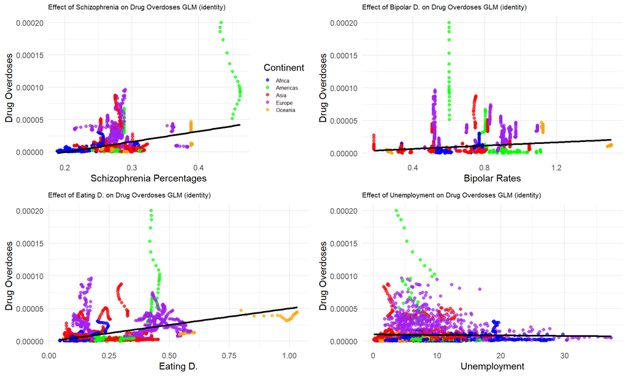

### **Description**

These scatter plots illustrates the relationship between **total drug deaths** and **mental health disorders** using a multivariate Generalized Linear Model (GLM). Each point represents a data observation, color-coded by continent, showing how mental health rates vary with drug-related deaths across different regions.

#### **6.2.2.1 Checking Normality Assumptions and Model Selection:**

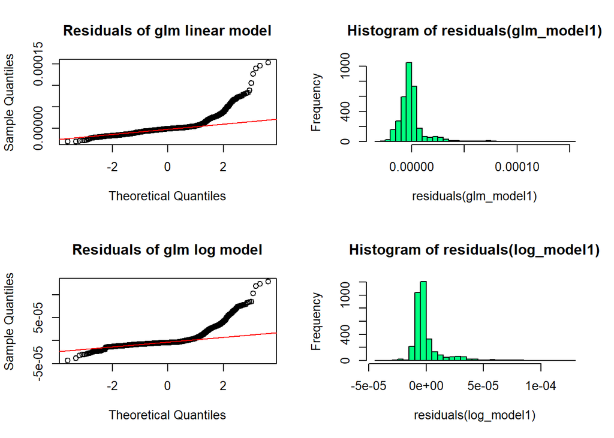

```
##
##  Shapiro-Wilk normality test
##
## data:  glm_model1[["residuals"]]
## W = 0.72569, p-value < 2.2e-16
```

```
##
##  Shapiro-Wilk normality test
##
## data:  log_model1[["residuals"]]
## W = 0.62121, p-value < 2.2e-16
```

```
##            df       AIC
## glm_model1  8 -65988.92
## log_model1  8 -65968.18
```

### **Decription**:

**Residual plots (QQ plots):** These assess whether the residuals (errors) from two Gaussia models (Log and Linear) follow a normal distribution.

**Histograms of residuals:** These plots shows where the residuals are centered.

**Shapiro-Wilks Normality Test:** This test checks whether the residuals follow a normal distribution.

**AIC:** This score allows us to compare the two models.

### 6.2.3 **Generalized Linear Mixed Effects Model:**

In this part, we wanted to control for random effects of country and year in our model.

**Model 1:**

```r
#GLMM model for drug overdose, control year,country
model.lme1 <- glmer(drugtot_adj ~ SchizophreniaRates + Depressive_DisorderRates +
                 Anxiety_DisorderRates + Bipolar_DisorderRates + Eating_DisorderRates +
                 unemployment + (1 | Year) + (1 | Country.Name),data = end_data)
```

**Model 2:**

```r
#GLMM Model for suicide rate, control year,country
model.lme2 <- glmer(suiciderates ~ SchizophreniaRates + Depressive_DisorderRates +
                 Anxiety_DisorderRates + Bipolar_DisorderRates + Eating_DisorderRates +
                 unemployment+ (1 |Year)
  + (1 | Country.Name),family=Gamma(link = "log"),
        data = end_data)
```

Summary of LMM (drug deaths) Results

| Predictor | Estimate | Std_Error | t_value |
| --- | --- | --- | --- |
| (Intercept) | 1.164000e-04 | 1.06924024470345e-05 | 10.8843330855456 |
| SchizophreniaRates | -3.599000e-04 | 3.12654934663433e-05 | -11.5117998288454 |
| Depressive_DisorderRates | -4.200000e-06 | 6.86648203733897e-07 | -6.07388906586742 |
| Anxiety_DisorderRates | -5.800000e-06 | 6.8418813482112e-07 | -8.42423158884979 |
| Bipolar_DisorderRates | 4.910000e-05 | 9.71659779097546e-06 | 5.05080913358216 |
| Eating_DisorderRates | -1.710000e-05 | 8.61558403269671e-06 | -1.98548518058015 |
| unemployment | -1.000000e-07 | 4.04415757273237e-08 | -2.58146927882011 |
| AIC | -7.223746e+04 |  |  |

```
## [1] "Random Effects Table GLMM Model 1"
```

```
##  Groups       Name        Variance   Std.Dev.
##  Country.Name (Intercept) 7.2383e-10 2.6904e-05
##  Year         (Intercept) 1.1801e-12 1.0863e-06
##  Residual                 2.0601e-11 4.5388e-06
```

Summary of GLMM-Gamma link (suicide rates)

| Predictor | Estimate | Std_Error | t_value | p_value |
| --- | --- | --- | --- | --- |
| (Intercept) | 2.2202837 | 0.375929231126691 | 5.90612138841373 | 3.50255933292217e-09 |
| SchizophreniaRates | -4.6717280 | 1.08043265453696 | -4.32394187895568 | 1.5326569088427e-05 |
| Depressive_DisorderRates | 0.2738953 | 0.0229307312996095 | 11.9444641684635 | 6.93961475490046e-33 |
| Anxiety_DisorderRates | -0.0509008 | 0.0225841019520886 | -2.25383235930742 | 0.0242067162522965 |
| Bipolar_DisorderRates | 0.8150008 | 0.374121089235369 | 2.17844127734184 | 0.0293731996296339 |
| Eating_DisorderRates | -1.7941463 | 0.31560961766756 | -5.68470094045389 | 1.31041765728557e-08 |
| unemployment | 0.0142135 | 0.0013226259828747 | 10.7464613304291 | 6.1578946814169e-27 |
| AIC | 11618.5800513 |  |  |  |

```
## [1] "Random Effects Table GLMM Model 2"
```

```
##  Groups       Name        Variance   Std.Dev.
##  Country.Name (Intercept) 0.07920864 0.281440
##  Year         (Intercept) 0.00034139 0.018477
##  Residual                 0.03736838 0.193309
```

## **7. Results**

To evaluate the fit of our models, we use standard metrics:

**p-values:** To determine the statistical significance of each predictor.

**AIC:** to choose between models

**Estimates**: direction and size of effects

### 7.1 **GLM Model for suicide deaths:**

- All of the variables show a significant main effect on suicide rates (p value < 0.05)
1. Depressive Disorder Rates have a positive and highly significant effect on suicide rates.
2. Anxiety and Bipolar Disorder Rates have a negative significant effect which is unexpected.
3. Eating Disorder Rates and Schizophrenia Rates have a strong positive effect on suicide rates.
4. Unemployment has a small but significant positive effect on suicide rates.

**Residuals:**

1. Gamma model residuals appear closer to a straight line than the Gaussian model, suggesting the Gamma model is a better fit.
2. Gaussian model residuals deviate significantly, particularly in the tails. The Gaussian model histogram is also skewed and has extreme values, reinforcing that normality is violated.
3. Shapiro-Wilks test results confirm non-normality (p-values < 2.2e-16), suggesting that a normal (Gaussian) assumption is inappropriate for modeling suicide rates.
4. Lower AIC score shows that Gamma distribution fits best to our data for the first model.
5. A log link means the effects of predictors are multiplicative rather than additive, making it more suitable for data with exponential trends.

### 7.2 **GLM Model for total drug overdoses:**

- Except Anxiety Disorders and unemployment, all of the variables show a significant main effect on drug overdoses (p value < 0.05)
1. Schizophrenia, Depression, and Eating Disorders are strong risk factors for drug overdose deaths. Higher rates of these disorders significantly increase drug overdose deaths.
2. Bipolar disorder appears to be linked with lower overdose rates which is unexpected.
3. Anxiety Disorder is only significant in the log model. This could suggest a non-linear relationship between anxiety and overdose rates.
4. Unemployment has little to no significant effect. This suggests that unemployment alone may not be a strong predictor of overdose deaths compared to mental health factors.

**Residuals:**

1. Both models show deviation from normality, especially in the tails (indicating non-normal residuals).
2. The GLM linear model shows stronger deviations at both ends, suggesting it might not be a great fit. The GLM log model also deviates but appears slightly more constrained.
3. Both histograms are skewed, meaning residuals are not normally distributed. The linear model histogram has a wider spread and longer tail, implying higher variance.
4. The log model histogram is more concentrated around zero, suggesting that the log transformation might have helped reduce variance.
5. Shapiro Wilks Test shows, both models residuals are not normally distributed.
6. Gaussian linear model has lower AIC scores and for simplicity we prefer this model, however neither model fits the data perfectly in terms of normality.

## **8. Chapter of Choice**

#### **Preprocessing of geospatial data and merging with our data:**

The geospatial data comes from package “spData”. After visual inspection we noticed that the country names of some were not same as with our merged data. Therefore, we renamed the countries that were not matching.Then we cleaned the NA values, also added years for 4 countries with missing years. Following this, we merged the data using sf package and saved as a .shp file.

Please check the script, preprocessing_world for detailed code.

You can access the interactive map Shiny app by clicking the link below:

*Please be patient, sometimes it takes a bit of time to load the graph.*

### [**Open the Interactive Map**](https://irmakoz.shinyapps.io/shiny_app/)

#### **Description:**

The interactive world map visualizes the trends in all our variables from the year 2000 to 2019. Through this graph, user has full control over the visualizations and can explore the data freely. By hovering over countries, the user can perceive the percentages of the selected variable in the data in that specific country. Since we wanted to create a user friendly design, the colors used in the interactive map are color-blind friendly as well. To achieve this we have used “viridis” package.

## **9. Summary and Conclusion**

### **9.1 Summary**

Above models examine the relationship between mental health disorders, unemployment, and both overdose deaths and suicide deaths across countries and years. The GLMM drug overdose model shows that bipolar disorder may increase overdose risk, while depression and anxiety unexpectedly show negative associations. Meanwhile, the GLMM suicide model indicates that depression, bipolar disorder, and unemployment significantly increase suicide rates, whereas schizophrenia and eating disorders show unexpected negative relationships. Both models highlight strong country-level variations, suggesting that additional factors may influence these outcomes.

### **8.3 Study Challenges**

Further refinement, including testing interactions and addressing potential multicollinearity, is needed to enhance the interpretation of our findings.